# Modelling the distribution of biodiversity under global climate change

biodiversityDS .

```r
# generate pseudo-absence and combine presences and background into a unique object
absences <- pseudoAbsences(rasterLayers = environmentalLayers, presences, n = 1000)
presences$PA <- 1
absences$PA <- 0
records <- rbind(absences, presences)
# Inspect spatial autocorrelation in the layers
sacAnalysis <- sac(environmentalLayers = environmentalLayers)
# extract environmental values and make an object with all information to model
modelData <- generateModelData(records, environmentalLayers, method = "blocks", bootstrapRounds = 10,
    sac = sacAnalysis$distance, paMinimum = 100, paRatio = 1)
```

S7 // Data-driven hyperparameter and monotonic constrains

biodiversityDS .

```r
# train the model and inspect the default hyperparameters used
model <- trainModel(modelData, algorithm = "brt")
model$hyperparameters
```

| bootstrap | learning.rate | interaction.depth | n.trees |
| --- | --- | --- | --- |
| 1 | 0.01 | 3 | 1000 |
| 2 | 0.01 | 3 | 1000 |
| 3 | 0.01 | 3 | 1000 |
| 4 | 0.01 | 3 | 1000 |
| 5 | 0.01 | 3 | 1000 |
| 6 | 0.01 | 3 | 1000 |
| 7 | 0.01 | 3 | 1000 |
| 8 | 0.01 | 3 | 1000 |
| 9 | 0.01 | 3 | 1000 |
| 10 | 0.01 | 3 | 1000 |

S7 // Data-driven hyperparameter and monotonic constrains

biodiversityDS .

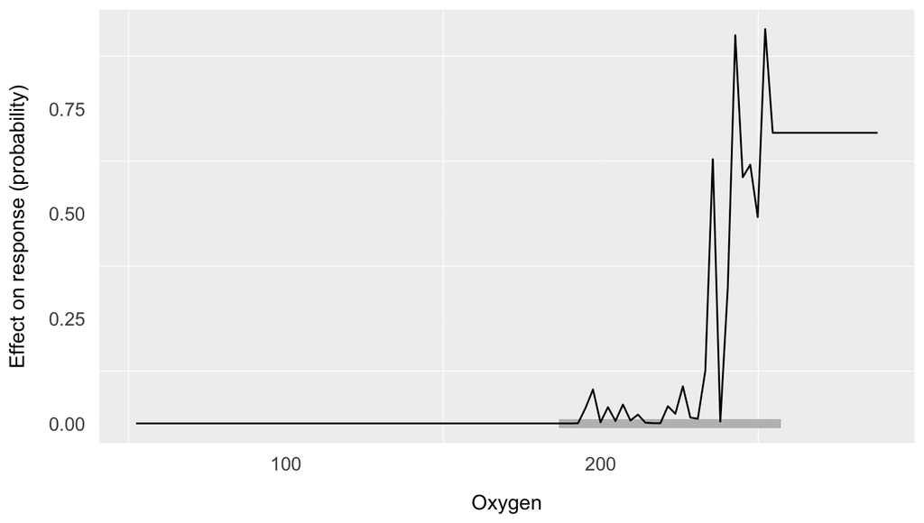

```r
# train the model with non-default hyperparameters
model <- trainModel(modelData, algorithm = "brt", hyperparameters = list(learning.rate = c(0.5)))
# inspect the partial dependence plot of temperature effect
partialPlotOxygen <- partialPlot(model, modelData, variablePlot = "Oxygen")
partialPlotOxygen$partialPlot
```

S7 // Data-driven hyperparameter and monotonic constrains

biodiversityDS .

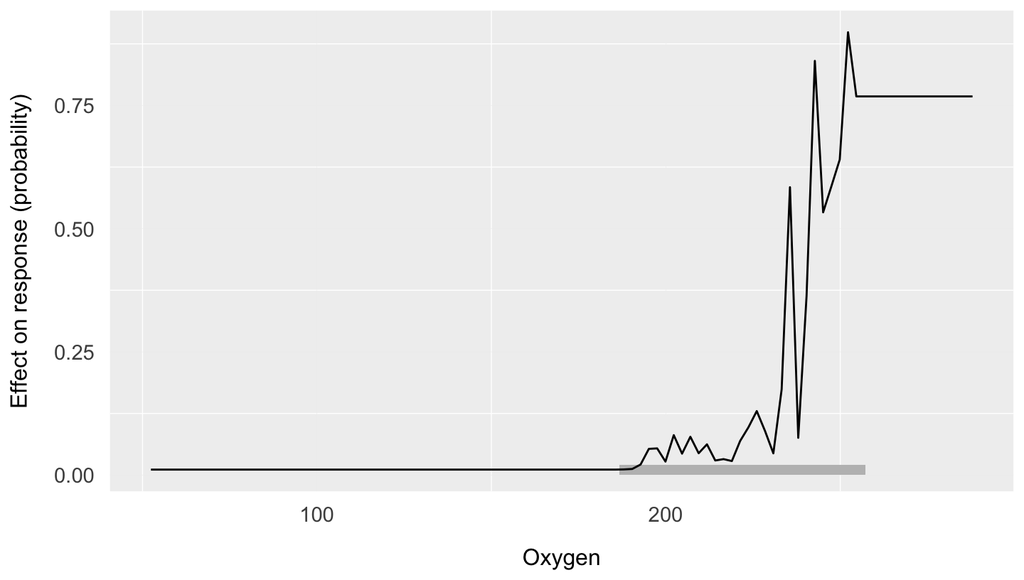

```r
# train the model with non-default hyperparameters
model <- trainModel(modelData, algorithm = "brt", hyperparameters = list(learning.rate = c(0.1)))
# inspect the partial dependence plot of temperature effect
partialPlotOxygen <- partialPlot(model, modelData, variablePlot = "Oxygen")
partialPlotOxygen$partialPlot
```

S7 // Data-driven hyperparameter and monotonic constrains

biodiversityDS .

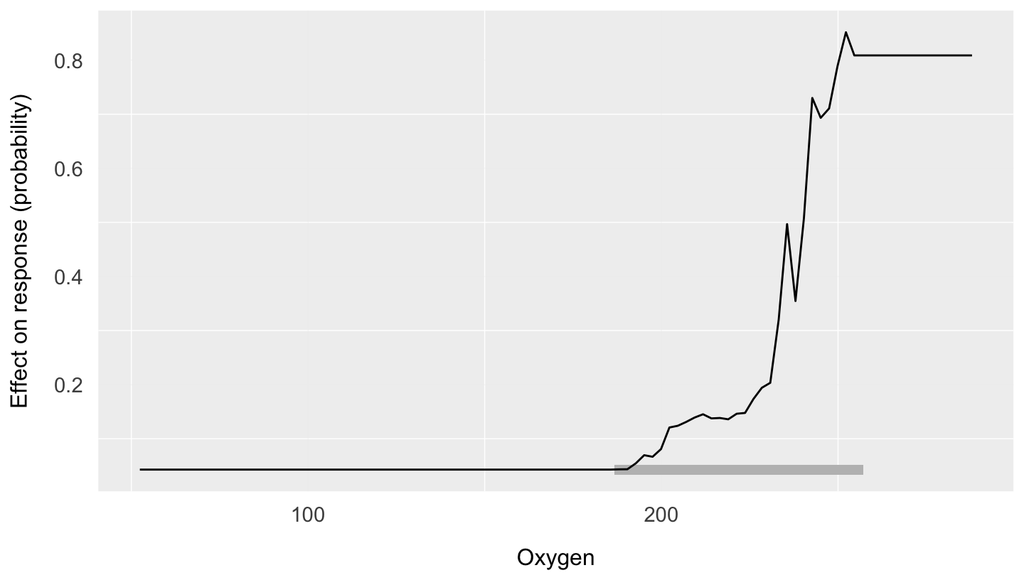

```r
# train the model with non-default hyperparameters
model <- trainModel(modelData, algorithm = "brt", hyperparameters = list(learning.rate = c(0.01)))
# inspect the partial dependence plot of temperature effect
partialPlotOxygen <- partialPlot(model, modelData, variablePlot = "Oxygen")
partialPlotOxygen$partialPlot
```

S7 // Data-driven hyperparameter and monotonic constrains

biodiversityDS .

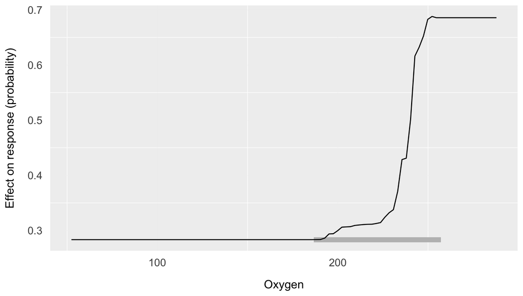

```r
# train the model with non-default hyperparameters
model <- trainModel(modelData, algorithm = "brt", hyperparameters = list(learning.rate = c(0.001)))
# inspect the partial dependence plot of temperature effect
partialPlotOxygen <- partialPlot(model, modelData, variablePlot = "Oxygen")
partialPlotOxygen$partialPlot
```

S7 // Data-driven hyperparameter and monotonic constrains

biodiversityDS .

To select the optimal hyperparameter, we can use a **grid search approach**. This is an approach that involves **training models with different hyperparameter values** and evaluating their performance in cross-validation.

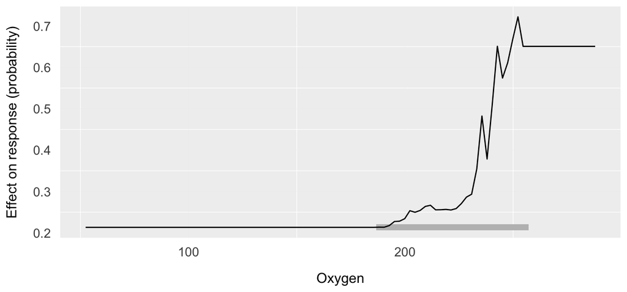

```r
# train the model with a set of hyperparameters
model <- trainModel(modelData, algorithm = "brt", hyperparameters = list(learning.rate = c(0.1,
    0.01, 0.001, 1e-04)))
# inspect the partial dependence plot of temperature effect
partialPlotOxygen <- partialPlot(model, modelData, variablePlot = "Oxygen")
partialPlotOxygen$partialPlot
```

S7 // Data-driven hyperparameter and monotonic constrains

biodiversityDS .

```r
# inspect the hyperparameters selected
model$hyperparameters
```

|  | bootstrap | learning.rate | interaction.depth | n.trees |
| --- | --- | --- | --- | --- |
| 2 | 1 | 1e-02 | 3 | 1000 |
| 1 | 2 | 1e-01 | 3 | 1000 |
| 4 | 3 | 1e-04 | 3 | 1000 |
| 21 | 4 | 1e-02 | 3 | 1000 |
| 22 | 5 | 1e-02 | 3 | 1000 |
| 23 | 6 | 1e-02 | 3 | 1000 |
| 3 | 7 | 1e-03 | 3 | 1000 |
| 41 | 8 | 1e-04 | 3 | 1000 |
| 42 | 9 | 1e-04 | 3 | 1000 |
| 31 | 10 | 1e-03 | 3 | 1000 |

S7 // Data-driven hyperparameter and monotonic constrains

biodiversityDS .

The grid search approach should be extended to include other hyperparameters.

```r
# Make hyperparameter list
hyperparametersList <- list(learning.rate = c(0.1, 0.01, 0.001), interaction.depth = c(2, 3,
    4), n.trees = seq(100, 1000, by = 100))
# train the model with a set of hyperparameters
model <- trainModel(modelData, algorithm = "brt", hyperparameters = hyperparametersList)
# inspect the hyperparameters selected
model$hyperparameters
```

```
##    bootstrap learning.rate interaction.depth n.trees
## 35         1         0.010                 4     400
## 64         2         0.100                 2     800
## 12         3         0.001                 2     200
## 34         4         0.100                 4     400
## 4          5         0.100                 3     100
## 86         6         0.010                 3    1000
## 14         7         0.010                 3     200
## 56         8         0.010                 2     700
## 81         9         0.001                 4     900
## 27        10         0.001                 4     300
```

S7 // Data-driven hyperparameter and monotonic constrains

biodiversityDS .

### Challenge 7.1

The main objective of this challenge is to perform data-driven **hyperparameter selection** in a brt model.

**Packages, data and functions to accomplish the challenge:**

**Files to use**  
**Functions to use**  
library  
download_multiple_layers  
rast  
plot  
studyRegion  
pseudoAbsences  
crop  
mask  
generateModelData  
trainModel  
list

S7 // Data-driven hyperparameter and monotonic constrains

## Monotonicity

## Monotonicity constrains in species distribution modelling

biodiversityDS .

Monotonicity constrains are used to ensure that the predicted response of a model is monotonic with respect to a given predictor variable. This means that the predicted response should either increase or decrease as the value of the predictor variable increases, but not both. This approach can force responses to meet ecological expectations.

```r
# inspect the name of layers
names(environmentalLayers)
```

```
## [1] "Temperature"  "Oxygen"       "Productivity"
```

```r
# monotonic constrains
monoton <- c("Temperature"=-1, # negative effect
             "Oxygen"=1, # positive effect
             "Productivity"=1) # positive effect
# train the model
model <- trainModel(modelData, algorithm ="brt", monotonicity=monoton)
```

S7 // Data-driven hyperparameter and monotonic constrains

biodiversityDS .

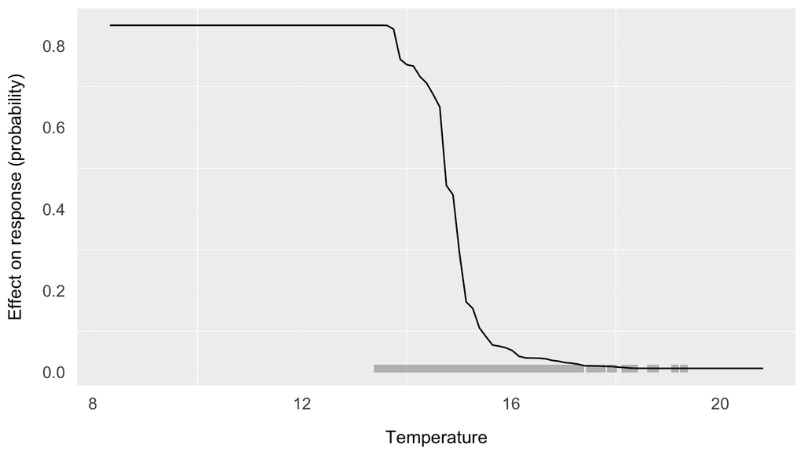

```r
# inspect the partial dependence plot of temperature effect
partialPlotTemperature <- partialPlot(model, modelData, variablePlot = "Temperature")
partialPlotTemperature$partialPlot
```

S7 // Data-driven hyperparameter and monotonic constrains

biodiversityDS .

```r
# monotonic constrains
monoton <- c("Temperature"=1, # positive effect
             "Oxygen"=1, # positive effect
             "Productivity"=1) # positive effect
# train the model
model <- trainModel(modelData, algorithm ="brt", monotonicity=monoton)
```

S7 // Data-driven hyperparameter and monotonic constrains

biodiversityDS .

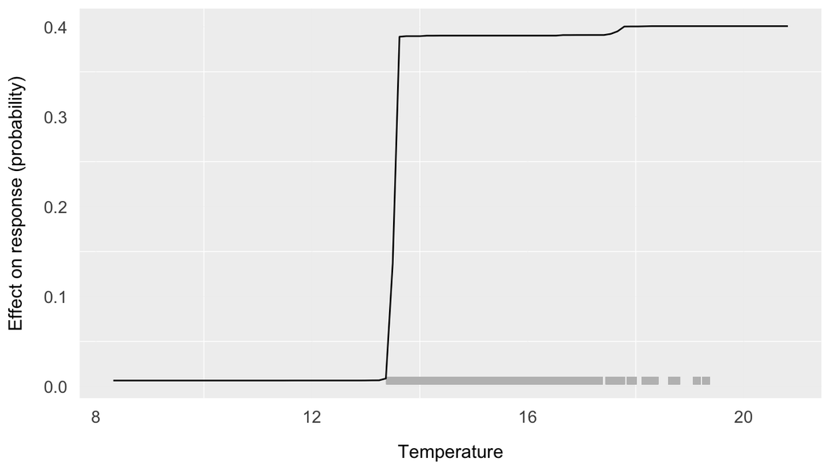

```r
# inspect the partial dependence plot of temperature effect
partialPlotTemperature <- partialPlot(model, modelData, variablePlot = "Temperature")
partialPlotTemperature$partialPlot
```

S7 // Data-driven hyperparameter and monotonic constrains

biodiversityDS .

### Challenge 7.2

The main objective of this challenge is to fit a brt model using monotonic constrains.

**Packages, data and functions to accomplish the challenge:**

**Files to use**  
**Functions to use**  
library  
download_multiple_layers  
rast  
plot  
studyRegion  
pseudoAbsences  
crop  
mask  
generateModelData  
trainModel  
partialPlot

S7 // Data-driven hyperparameter and monotonic constrains